# Brecha de acceso y uso en estudiantes

Equipo Rojo fuego

07/2020

$~$

En el siguiente informe se estudiarán las brechas de acceso y uso en estudiantes de CABA según datos obtenidos en las pruebas Aprender 2017.

$~$

# **Preparación**

$~$

Corremos las librerías:

```r
library(readr)
library(tidyverse)
library(ggplot2)
library(plotly)
```

Bajamos los datasets que vamos a usar:

```r
Aprender <- read_delim("https://media.githubusercontent.com/media/Agustin-Bulzomi/Projects/main/Programming/Support_Files/Aprender%202017%20-%20Secundaria.csv", "\t", escape_double = FALSE, trim_ws = TRUE)
```

Comenzaremos preparando los datasets y procesándolos para obtener la información que necesitamos, para finalmente presentar todos los gráficos que expongan lo analizado.

$~$

# **Análisis de brecha de acceso**

$~$

Primero, veamos cómo están los alumnos de CABA con respecto a la brecha de acceso: ¿Cuántos tienen computadora e internet?

Filtramos por alumnos de CABA:

```r
Alumnos_CABA <- filter(Aprender, cod_provincia == 2)
```

Analizamos cuántos tienen computadora en su casa:

```r
Computadoras_CABA <- group_by(Alumnos_CABA, ap8b) %>%
  summarise(Alumnos_con_computadora = n())
```

Ahora buscamos cuántos tienen internet en su casa:

```r
Internet_CABA <- group_by(Alumnos_CABA, ap7d) %>%
  summarise(Alumnos_con_internet = n ())
```

$~$

# **Análisis de brecha de uso**

$~$

En segundo lugar, veamos cuántos alumnos aseguran usar TICs en el colegio. Puesto que solo buscamos analizar los que respondieron “sí” o “no”, hacemos drop_na para emprolijar el gráfico del final:

```r
TICs_CABA <- group_by(Alumnos_CABA, ap33b) %>%
  summarise(Uso_TICs = n()) %>%
  drop_na() %>%
  filter(ap33b == 1 | ap33b == 2)
```

Ahora que tenemos el uso de las TICs en el colegio, queremos ver qué respondieron sobre la necesidad de aprender nuevas tecnologías. Solo buscamos los “sí”, “no” y “en blanco”.

```r
Aprender_Nuevas_Tecnologias_CABA <- group_by(Alumnos_CABA, ap37a) %>%
  summarise(Aprender_Tecnologias = n()) %>%
  drop_na() %>%
  filter(ap37a == 1 | ap37a == 2 | ap37a == -9)
```

$~$

# **Unión de ambas brechas**

$~$

En tercer lugar, queremos analizar ambas tablas en conjunto. Primero, renombramos las columnas para poder unirlas:

```r
Computadoras_CABA <- rename(Computadoras_CABA, Codigos=ap8b)
Internet_CABA <- rename(Internet_CABA, Codigos=ap7d)
TICs_CABA <- rename(TICs_CABA, Codigos=ap33b)
Aprender_Nuevas_Tecnologias_CABA <- rename(Aprender_Nuevas_Tecnologias_CABA, Codigos=ap37a)
```

Ahora, unimos en dos tablas distintas: una para ver la brecha de acceso a computadoras e internet…

```r
Computadoras_Internet_CABA <- left_join(Computadoras_CABA, Internet_CABA, by="Codigos")
```

… y otra para ver el uso de TICs, en contraposición a las ganas de aprender nuevas tecnologías:

```r
TICs_Aprender_CABA <- left_join(TICs_CABA, Aprender_Nuevas_Tecnologias_CABA, by="Codigos")
```

Luego, podemos ver los cuatro datos juntos en una sola tabla:

```r
Final_CABA <- left_join(Computadoras_Internet_CABA, TICs_Aprender_CABA, by="Codigos")
```

Finalmente, renombramos las respuestas para que sea más claro visualmente:

```r
Final_CABA$Codigos[Final_CABA$Codigos == 1] <- "Sí"
Final_CABA$Codigos[Final_CABA$Codigos == 2] <- "No"
Final_CABA$Codigos[Final_CABA$Codigos == -1] <- "No corresponde"
Final_CABA$Codigos[Final_CABA$Codigos == -6] <- "Multimarca"
Final_CABA$Codigos[Final_CABA$Codigos == -9] <- "Blanco"
View(Final_CABA)
```

$~$

# **Análisis de ambas brechas**

$~$

Ya unidas, vamos a filtrar por nivel socioecónomico para ver si hay alguna diferencia notable. En primer lugar, filtramos por alumnos de CABA con Nivel Socioeconómico bajo:

```r
Indice_SEB <- filter(Alumnos_CABA, isocioa == 1)
```

Habiendo obtenido una tabla de Nivel Socioeconómico bajo, analizamos dos parámetros. Comenzamos con las ganas de aprender nuevas tecnologías:

```r
NT_Indice_SE <- group_by(Indice_SEB, ap37a) %>%
  summarise(Nuevas_Tecnologias = n())

NT_Indice_SE <- rename(NT_Indice_SE, Codigos=ap37a)

NT_Indice_SE$Codigos[NT_Indice_SE$Codigos == 1] <- "Sí"
NT_Indice_SE$Codigos[NT_Indice_SE$Codigos == 2] <- "No"
NT_Indice_SE$Codigos[NT_Indice_SE$Codigos == -1] <- "No corresponde"
NT_Indice_SE$Codigos[NT_Indice_SE$Codigos == -6] <- "Multimarca"
NT_Indice_SE$Codigos[NT_Indice_SE$Codigos == -9] <- "Blanco"

View(NT_Indice_SE)
```

Seguimos con la disponibilidad de internet:

```r
Computadoras_Indice_SE <- group_by(Indice_SEB, ap7d) %>%
  summarise(Disponibilidad_Internet = n()) %>%
  rename(Codigos=ap7d)

Computadoras_Indice_SE$Codigos[Computadoras_Indice_SE$Codigos == 1] <- "Sí"
Computadoras_Indice_SE$Codigos[Computadoras_Indice_SE$Codigos == 2] <- "No"
Computadoras_Indice_SE$Codigos[Computadoras_Indice_SE$Codigos == -1] <- "No corresponde"
Computadoras_Indice_SE$Codigos[Computadoras_Indice_SE$Codigos == -6] <- "Multimarca"
Computadoras_Indice_SE$Codigos[Computadoras_Indice_SE$Codigos == -9] <- "Blanco"

View (Computadoras_Indice_SE)
```

En segundo lugar, volvemos a la tabla original para filtrar y realizar el mismo análisis en Nivel Socioeconómico alto:

```r
Indice_SEA <- filter(Alumnos_CABA, isocioa == 3) %>%
  group_by(ap37a) %>%
  summarise(Nuevas_Tecnologias = n()) %>%
  rename(Codigos=ap37a)

Indice_SEA$Codigos[Indice_SEA$Codigos == 1] <- "Sí"
Indice_SEA$Codigos[Indice_SEA$Codigos == 2] <- "No"
Indice_SEA$Codigos[Indice_SEA$Codigos == -1] <- "No corresponde"
Indice_SEA$Codigos[Indice_SEA$Codigos == -6] <- "Multimarca"
Indice_SEA$Codigos[Indice_SEA$Codigos == -9] <- "Blanco"

View(Indice_SEA)
```

No vemos diferencias significativas al analizar según índice socioeconómico.

$~$

# **Gráficos**

$~$

Para graficar, utilizaremos siempre la paleta de colores del diseño de marca Tech Truck

$~$

En primer lugar, veamos la disponibilidad de computadoras en el hogar:

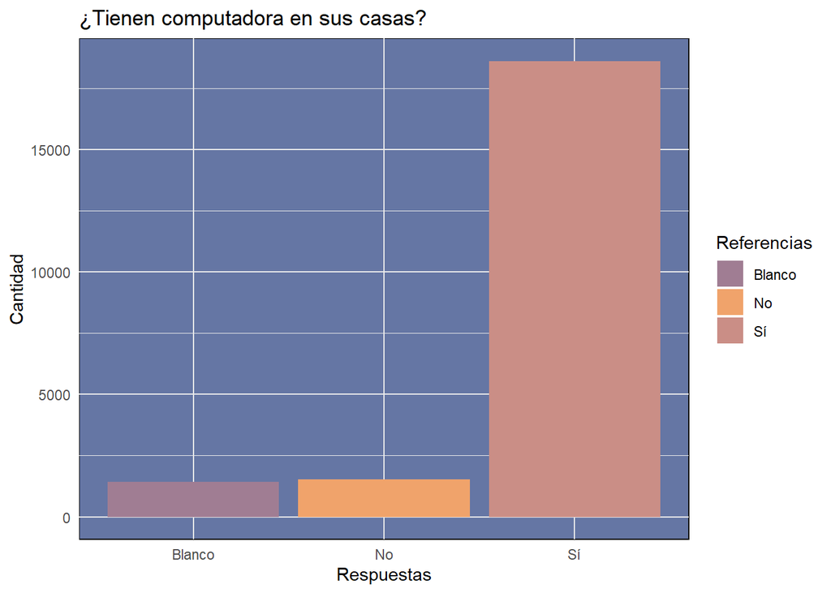

```r
Computadoras_CABA$Codigos[Computadoras_CABA$Codigos == 1] <- "Sí"
Computadoras_CABA$Codigos[Computadoras_CABA$Codigos == 2] <- "No"
Computadoras_CABA$Codigos[Computadoras_CABA$Codigos == -9] <- "Blanco"

Grafico_Computadoras <- drop_na(Computadoras_CABA) %>%
  filter(Codigos == "Sí" | Codigos == "No" | Codigos == "Blanco") %>%
  ggplot(aes(x=reorder (Codigos, Alumnos_con_computadora), y=Alumnos_con_computadora, fill=Codigos))+
  geom_bar(stat = "identity")+
  scale_fill_manual(values=c("#A07D93", "#F0A36b", "#CA8E86"))+
  theme_minimal() +
  theme(panel.background = element_rect(fill = '#6576A4')) +
  ylab("Cantidad")+
  xlab("Respuestas")+
  labs(fill = "Referencias")+
  ggtitle("¿Tienen computadora en sus casas?")

Grafico_Computadoras
```

## Gráfico 1: Disponibilidad de computadoras en el hogar

$~$

En segundo lugar, veamos la disponibilidad de internet en el hogar:

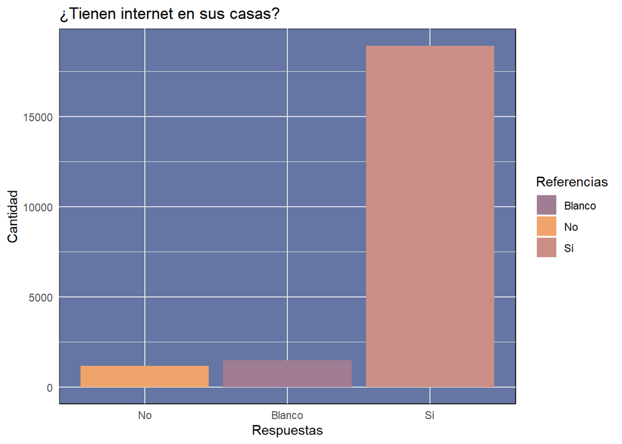

```r
Internet_CABA$Codigos[Internet_CABA$Codigos == 1] <- "Sí"
Internet_CABA$Codigos[Internet_CABA$Codigos == 2] <- "No"
Internet_CABA$Codigos[Internet_CABA$Codigos == -9] <- "Blanco"

Grafico_Internet <- drop_na(Internet_CABA) %>%
  filter(Codigos == "Sí" | Codigos == "No" | Codigos == "Blanco") %>%
  ggplot(aes(x= reorder(Codigos, Alumnos_con_internet), y=Alumnos_con_internet, fill=Codigos))+
  geom_bar(stat = "identity")+
  scale_fill_manual(values=c("#A07D93", "#F0A36b", "#CA8E86"))+
  theme_minimal() +
  theme(panel.background = element_rect(fill = '#6576A4')) +
  ylab("Cantidad")+
  xlab("Respuestas")+
  labs(fill = "Referencias")+
  ggtitle("¿Tienen internet en sus casas?")

Grafico_Internet
```

## Gráfico 2: Disponibilidad de internet en el hogar

$~$

En tercer lugar, veamos el uso de TICs en la escuela:

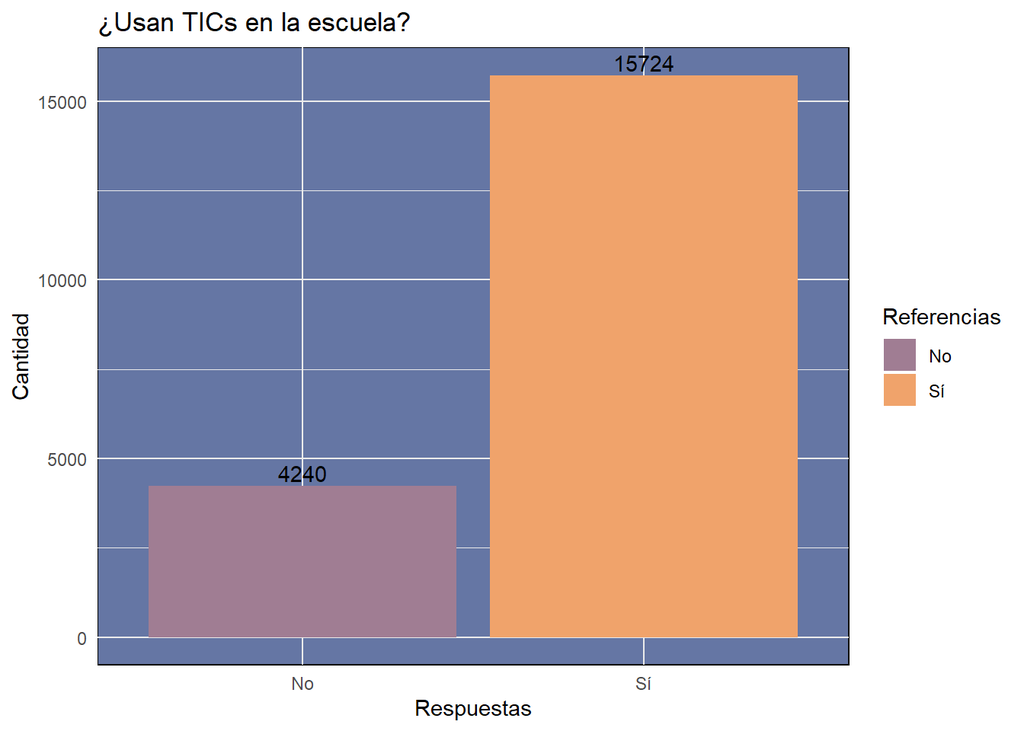

```r
TICs_CABA$Codigos[TICs_CABA$Codigos == 1] <- "Sí"
TICs_CABA$Codigos[TICs_CABA$Codigos == 2] <- "No"
TICs_CABA$Codigos[TICs_CABA$Codigos == -1] <- "No corresponde"
TICs_CABA$Codigos[TICs_CABA$Codigos == -9] <- "Blanco"

Grafico_TICs <- ggplot(TICs_CABA, aes(x=reorder (Codigos, Uso_TICs), y=Uso_TICs, fill=Codigos))+
  geom_bar(stat = "identity")+
  scale_fill_manual(values=c("#A07D93", "#F0A36b", "#CA8E86"))+
  theme_minimal() +
  theme(panel.background = element_rect(fill = '#6576A4')) +
  geom_text(aes(label=Uso_TICs), position=position_dodge(width=0.9), vjust=-0.25) +
  ylab("Cantidad")+
  xlab("Respuestas")+
  labs(fill = "Referencias")+
  ggtitle("¿Usan TICs en la escuela?")

Grafico_TICs
```

## Gráfico 3: Uso de TICs en la escuela

$~$

Finalmente, hagamos un gráfico interactivo para detallar los resultados de la encuesta sobre la enseñanza de TICs en las escuelas:

```r
Aprender_Nuevas_Tecnologias_CABA$Codigos[Aprender_Nuevas_Tecnologias_CABA$Codigos == 1] <- "Sí"
Aprender_Nuevas_Tecnologias_CABA$Codigos[Aprender_Nuevas_Tecnologias_CABA$Codigos == 2] <- "No"
Aprender_Nuevas_Tecnologias_CABA$Codigos[Aprender_Nuevas_Tecnologias_CABA$Codigos == -1] <- "No corresponde"
Aprender_Nuevas_Tecnologias_CABA$Codigos[Aprender_Nuevas_Tecnologias_CABA$Codigos == -9] <- "Blanco"


Grafico_Nuevas_Tecnologias <-ggplot(Aprender_Nuevas_Tecnologias_CABA, aes(x=reorder (Codigos, Aprender_Tecnologias), y=Aprender_Tecnologias, fill=Codigos))+
  geom_bar(stat = "identity")+
  scale_fill_manual(values=c("#A07D93", "#F0A36b", "#CA8E86"))+
  theme_minimal() +
  theme(panel.background = element_rect(fill = '#6576A4')) +
  ylab("Cantidad")+
  xlab("Respuestas")+
  labs(fill = "Referencias")+
  ggtitle("¿Deberían enseñar nuevas tecnologías en la escuela?")

ggplotly(Grafico_Nuevas_Tecnologias)
```

[interactive chart not shown]

## Gráfico interactivo 1: Encuesta sobre la enseñanza de TICs en las escuelas